# exercise_27-28_csu

Author

Cameron McLaughlin

Published

May 7, 2025

# Cache la Poudre River

## libraries.

```r
# libraries
library(sf)
library(osmdata)
library(dplyr)
library(ggplot2)
library(terra)
library(AOI)
```

## 1. Extract Rivers from OpenStreetMap

Fort Collins boundary and extract all waterways

```r
#Fort Collins boundary

#Fort Collins boundary
fc <- AOI::geocode("Fort Collins", bbox = TRUE) |>
  st_union() |>
  st_as_sf()

#waterways from openstreetmap
foco_rivers <- osmdata::opq(st_bbox(st_transform(fc, 4326))) |>
  add_osm_feature("waterway") |>
  osmdata_sf()
```

## 1. Filter for poudre

Filter for Poudre and merge the lines into single line object

```r
# Filter for Cache la Poudre River and merge lines
poudre_river <- foco_rivers$osm_lines |>
  filter(grepl("Cache la Poudre|Poudre", name, ignore.case = TRUE)) |>
  st_union() |>
  st_as_sf()
```

## 2. Calc River Length

Use `st_length()` to calc the length of the poudre

```r
# Project river to UTM zone (e.g., EPSG:26913)
poudre_river_proj <- st_transform(poudre_river, 26913)

# Calculate river length in meters
river_length <- st_length(poudre_river_proj)
print(river_length)
```

```
243300.1 [m]
```

## 3. River line to Points

Convert river line to POINT object

```r
# Convert river to points
poudre_pts <- st_cast(poudre_river_proj, "POINT")
```

## 4. Define DEM

Read the DEM file

```r
#Read DEM
#VSI-prefixed URL
url <- 'https://raw.githubusercontent.com/mikejohnson51/csu-ess-330/refs/heads/main/resources/foco-elev-cm.tif'
vsi_url <- paste0('/vsicurl/', url)

# Read raster data
elev_rast <- rast(vsi_url)

#values into data frame
elev_df <- values(elev_rast, dataframe = TRUE)
colnames(elev_df) <- "elevation_cm"
```

## 5/6 Extract River Profile

Extract the elevation values from the DEM at the points along the river.

```r
#take elev values from raster at the river points
poudre_pts2 <- st_transform(poudre_pts, crs(elev_rast))

# Extract elevation values from DEM
elevation_values <- terra::extract(elev_rast, poudre_pts2)

# Combine river points and elevation, then remove rows with NA elevation
poudre_profile <- bind_cols(poudre_pts, elevation_values) |>
  filter(!is.na(dem))
```

## 7. Add ID Column

Add ID column

```r
# Add ID column
poudre_profile <- poudre_profile |>
  mutate(ID = 1:n())
```

## 8-9 Sinuosity

Calculate the sinuosity of the river by dividing the length by the straight-line distance.

```r
#calc straight-line distance between first and last points
start_point <- poudre_pts[1,]
end_point <- poudre_pts[nrow(poudre_pts),]
straight_line_dist <- st_distance(start_point, end_point)

#calc sinuosity (river length / straight-line distance)
sinuosity <- as.numeric(river_length / straight_line_dist)
print(sinuosity)
```

```
[1] 18.21781
```

## 10. Compute Slope

Calc slope of river

```r
#convert cm to m for elev
start_elev <- poudre_profile$dem[poudre_profile$ID == 1] / 100
end_elev <- poudre_profile$dem[poudre_profile$ID == max(poudre_profile$ID)] / 100
elev_change <- start_elev - end_elev

slope <- elev_change / as.numeric(river_length)
print(slope)
```

```
[1] -0.0003979448
```

The slope is -0.0003m elevation over 1-m river length.

## 11. Line Plot of River Profile

Create a line plot of the elevation values along the river.

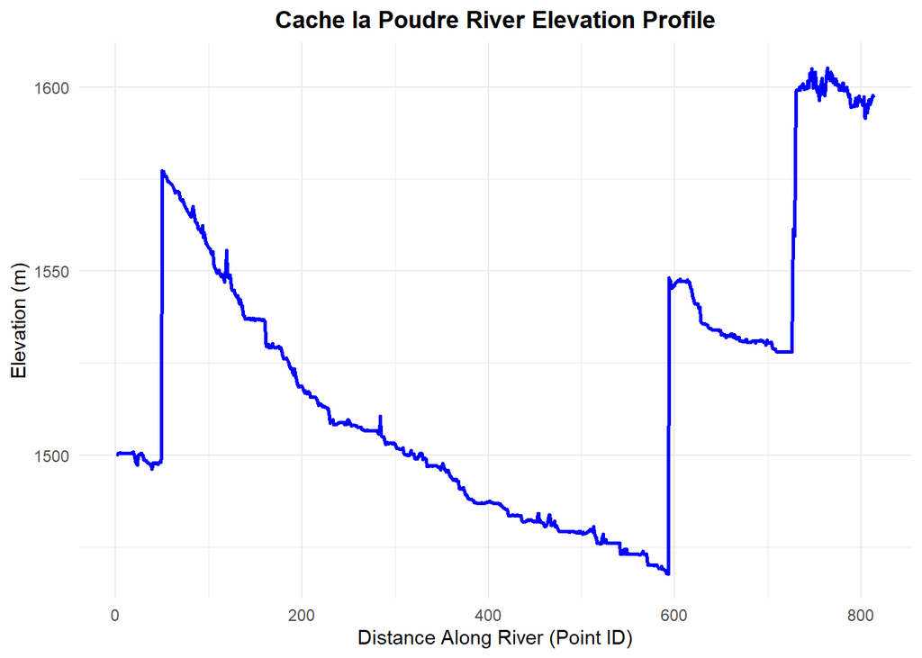

```r
# Convert elevation from cm to meters
poudre_profile <- poudre_profile |>
  mutate(dem_m = dem / 100)

elev_plot <- ggplot(poudre_profile, aes(x = ID, y = dem_m)) +
  geom_line(color = "blue", linewidth = 1) +
  labs(title = "Cache la Poudre River Elevation Profile",
       x = "Distance Along River (Point ID)",
       y = "Elevation (m)") +
  theme_minimal() +
  theme(plot.title = element_text(hjust = 0.5, face = "bold"))

print(elev_plot)
```

## 12. Spatial Map of River

Create a spatial map of the river colored by elevation.

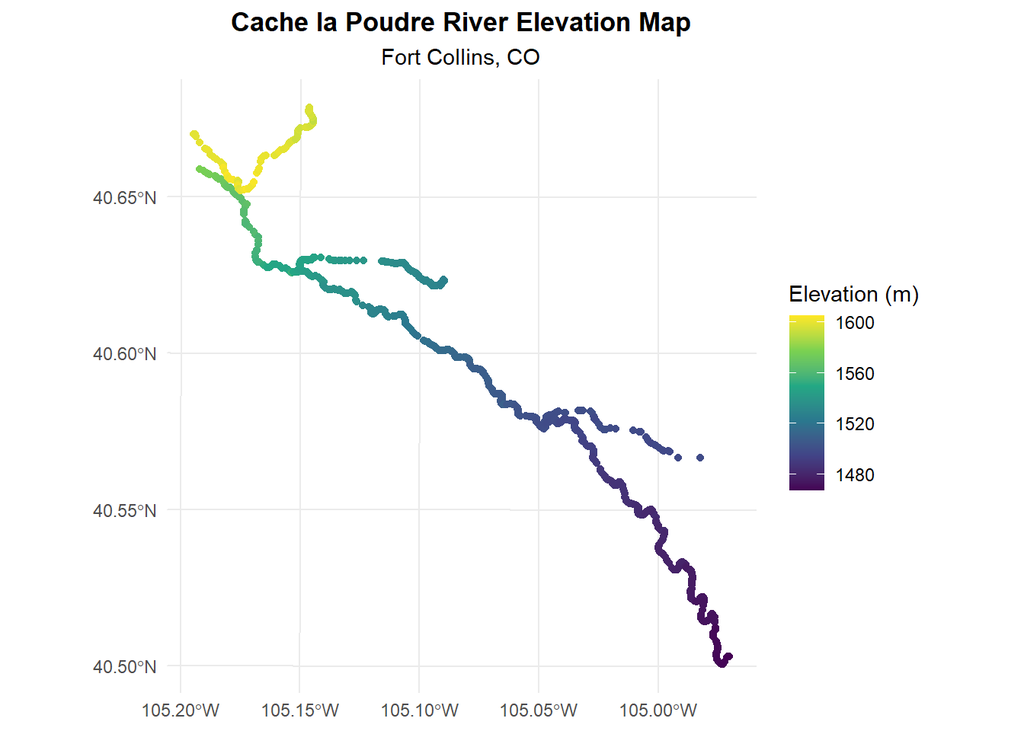

```r
elev_map <- ggplot() +
  geom_sf(data = poudre_profile, aes(color = dem_m)) +
  scale_color_viridis_c(name = "Elevation (m)") +
  labs(title = "Cache la Poudre River Elevation Map",
       subtitle = "Fort Collins, CO") +
  theme_minimal() +
  theme(plot.title = element_text(hjust = 0.5, face = "bold"),
        plot.subtitle = element_text(hjust = 0.5))

print(elev_map)
```